# Cluster biology: annotation, visualization, and immune-reconstitution link

Deep immune cell phenotyping predicts influenza vaccine immunogenicity in HCT recipients

July 21, 2026

# 1 What this notebook does

This notebook gives the meta-clusters their biological identities and shows that they behave like real immune-cell populations. It produces:

- **Supplementary Table (meta-cluster annotations)** – the cell-type label and differentiating markers for each of the 33 meta-clusters.
- **Figure 3** – the UMAP embedding of all cells, colored by immune lineage.
- **Supplementary Figure (faceted UMAP)** – each meta-cluster highlighted individually, confirming that populations occupy distinct regions.
- **Supplementary Figure (marker heatmap)** – the biclustered marker-expression profile of each meta-cluster.
- The **cluster-to-time-post-transplant regression**, which shows that cellular composition tracks immune reconstitution.

The annotations come from canonical marker combinations (CD3 for T cells, CD4/CD8 for the T-cell split, CD19/CD20 for B cells, CD38/CD138 for plasmablasts, CD57 for NK cells, HLA-DR/CD86 for antigen-presenting cells). Because the 30-marker panel has no dedicated myeloid markers (CD14, CD16, CD11c, CD123), the APC/monocyte labels are inferred by exclusion (CD3-CD19-HLA-DR+) and should be read with that caveat.

```r
# Edit these to your local copy of the intermediate data (not distributed; see
# README, Data Availability). All objects below are precomputed atlas outputs;
# nothing here re-runs clustering.
FAST <- "/fast/datasets/flu_cellular_prediction"
REPO <- "/home/amir/repo/flu-cellular-prediction"

BIO_FILE  <- file.path(REPO, "results", "final_atlas_production", "biology_production_90203bf3.RData")
ANN_FILE  <- file.path(REPO, "results", "reports", "cluster_annotations_corrected.csv")
CTIME_FILE <- file.path(FAST, "post_hoc_5000", "cluster_time", "E2_cluster_time.RData")
```

```r
# --- Production-atlas biology object (cell-level UMAP + per-cluster profiles) ---
if (file.exists(BIO_FILE)) {
  bio <- new.env(parent = emptyenv()); load(BIO_FILE, envir = bio)
} else {
  stop("Biology object not found. It is produced by the production-atlas ",
       "pipeline (notebook 01) and available from the corresponding author.")
}
umap_dt        <- as.data.table(bio$umap_dt)          # per-cell UMAP coordinates
cell_meta      <- as.integer(bio$dt_keep$meta)        # per-cell meta-cluster id
marker_profiles <- bio$marker_profiles                # 33 clusters x 30 markers (z-space mean)
means_original <- as.data.table(bio$means_original)   # per-cluster mean on original scale
marker_names   <- bio$marker_names
selected_k     <- bio$selected_k

# --- Curated biological annotations (cell type + broad lineage per cluster) ---
ann <- as.data.table(read.csv(ANN_FILE, stringsAsFactors = FALSE))
ann[, cluster_id := as.integer(cluster_id)]
setorder(ann, cluster_id)
```

# 2 Supplementary Table: meta-cluster annotations

Each meta-cluster is labeled with its broad lineage, a cell-type name, and its most strongly expressed markers (mean expression on the original arcsinh scale). The table is grouped by lineage. Plasmablasts are listed with the B cells.

```r
# Top differentiating markers per cluster, from the original-scale means.
mo <- copy(means_original)
mcols <- setdiff(names(mo), "meta")
top_markers <- vapply(seq_len(nrow(mo)), function(i) {
  vals <- unlist(mo[i, ..mcols]); vals <- sort(vals, decreasing = TRUE)[1:4]
  paste(sprintf("%s=%.1f", names(vals), vals), collapse = ", ")
}, character(1))
marker_dt <- data.table(cluster_id = as.integer(mo$meta), key_markers = top_markers)

# Order lineages the way the manuscript groups them.
lin_order <- c("B cell", "Plasmablast", "CD4+ T", "CD8+ T",
               "APC/Monocyte", "NK cell", "Other")
annot_tab <- merge(ann[, .(cluster_id, broad_lineage, annotation)],
                   marker_dt, by = "cluster_id")
annot_tab[, broad_lineage := factor(broad_lineage, levels = lin_order)]
setorder(annot_tab, broad_lineage, cluster_id)
setnames(annot_tab, c("cluster_id", "broad_lineage", "annotation", "key_markers"),
         c("Cluster", "Lineage", "Cell type", "Key markers (top mean expression)"))
kable(annot_tab, caption =
  "Supplementary Table. Biological annotation of the 33 meta-clusters.")
```

Supplementary Table. Biological annotation of the 33 meta-clusters.

| Cluster | Lineage | Cell type | Key markers (top mean expression) |
| --- | --- | --- | --- |
| 8 | NA | Activated CD4+CD8+ T cell | CD3=3.9, CD127=2.8, CD38=2.6, HLA-DR=2.3 |
| 20 | NA | Double-negative memory T (CXCR3+) | CD3=3.9, CD127=2.2, CD27=2.0, CD28=1.6 |
| 32 | NA | Activated CD38hi double-negative T (TIGIT+) | CD38=4.1, CD27=4.0, CD3=3.8, CD28=3.2 |
| 4 | B cell | CD21-low B cell (CCR6+ BTLA+) | CD19=5.0, CD20=4.7, HLA-DR=3.8, CD127=1.9 |
| 9 | B cell | Activated follicular B (CD38+) | CD19=4.4, HLA-DR=4.2, CD20=4.1, CXCR5=3.2 |
| 12 | B cell | Cycling germinal-center-like B | CD19=4.2, HLA-DR=4.0, CD20=3.7, CXCR5=3.1 |
| 13 | B cell | Follicular B (CXCR5+ CD21+ CCR6+) | CD19=4.4, HLA-DR=4.0, CD20=3.9, CXCR5=3.4 |
| 26 | B cell | Follicular B | CD19=3.7, HLA-DR=3.5, CD20=3.4, CXCR5=2.5 |
| 30 | B cell | Transitional B | CD20=4.1, CD19=4.1, CD38=3.5, HLA-DR=3.5 |
| 31 | B cell | Activated follicular B (CD25+) | CD19=4.3, HLA-DR=3.9, CD20=3.6, CXCR5=3.0 |
| 28 | Plasmablast | Plasmablast (CD19+ CD38++ CD27+) | CD38=4.5, CD19=3.7, HLA-DR=3.7, Ki-67=2.5 |
| 6 | CD4+ T | ICOS+ effector-memory CD4+ T | CD4=4.0, CD3=3.8, CD127=2.9, CD45RO=2.8 |
| 7 | CD4+ T | CD4+ T cell | CD4=3.2, CD3=3.2, CD27=2.0, CD127=2.0 |
| 10 | CD4+ T | CCR7+ CD25+ central-memory CD4+ T | CD3=4.0, CD4=3.6, CD27=3.3, CD127=2.6 |
| 14 | CD4+ T | Naive CD4+ T | CD3=4.1, CD4=3.5, CD27=3.1, CD127=2.6 |
| 16 | CD4+ T | Activated CCR4+ memory CD4+ T | CD4=3.8, CD3=3.7, CD28=2.8, CD127=2.7 |
| 25 | CD4+ T | PD-1+ TIGIT+ exhausted memory CD4+ T | CD3=4.0, CD4=4.0, CD27=3.2, CD45RO=3.0 |
| 33 | CD4+ T | CD57+ senescent memory CD4+ T | CD4=4.1, CD3=3.8, CD57=3.5, CD45RO=2.3 |
| 1 | CD8+ T | Exhausted effector-memory CD8+ T | CD3=3.7, CD8=3.6, CD27=2.8, CD45RO=2.7 |
| 15 | CD8+ T | CD57+ TEMRA-like CD8+ T | CD3=3.7, CD57=3.4, CD8=3.2, CD127=1.8 |
| 18 | CD8+ T | TIGIT+ exhausted CD8+ T | CD3=3.6, CD8=3.0, CD27=2.2, TIGIT=2.0 |
| 22 | CD8+ T | Effector CD8+ T | CD8=3.3, CD3=3.1, CD27=1.9, CD127=1.7 |
| 27 | CD8+ T | Naive CD8+ T | CD8=3.8, CD3=3.6, CD27=3.1, CD127=2.6 |
| 2 | APC/Monocyte | Classical monocyte | CCR2=3.1, HLA-DR=2.7, CD38=2.5, CD127=1.6 |
| 5 | APC/Monocyte | Activated classical monocyte (CD69+) | HLA-DR=3.3, CCR2=3.2, CD38=2.8, CD127=2.3 |
| 11 | APC/Monocyte | Monocyte-like APC (CD69+) | CD127=2.0, CD69=1.8, CD38=1.8, HLA-DR=1.5 |
| 17 | APC/Monocyte | Activated classical monocyte (CD38+ CD86+) | HLA-DR=3.3, CCR2=3.2, CD127=2.7, CD38=2.6 |
| 23 | APC/Monocyte | Dendritic cell-like APC | HLA-DR=3.3, CD127=2.0, CD86=1.8, CD4=1.7 |
| 21 | NK cell | NK cell | CD57=3.7, CD38=3.0, CD127=1.7, CD137=1.3 |
| 3 | Other | CD38+ lineage-negative immature-like | CD38=3.1, CD127=1.8, CD28=1.3, CXCR3=0.9 |
| 19 | Other | Low-expression lineage-negative population | CD127=1.8, HLA-DR=1.0, CD38=0.9, CD28=0.8 |
| 24 | Other | TIGIT+ CD38+ lineage-negative population | CD38=3.1, TIGIT=1.9, CD127=1.8, CD28=1.3 |
| 29 | Other | Activated lineage-negative population (CD138+ CXCR3+) | CD38=3.1, CD127=2.4, CD138=1.9, CXCR3=1.7 |

The atlas resolves coherent populations across all major lineages: CD4+ T cells, B cells (including follicular, germinal-center-like, transitional, and CD21-low subsets), CD8+ T cells, APC/monocyte populations, a plasmablast cluster, an NK cluster, and a set of double-negative / lineage-negative populations.

# 3 Figure 3: UMAP colored by immune lineage

The UMAP places each cell in two dimensions so that cells with similar marker expression sit near one another. Coloring by the broad lineage of each cell’s meta-cluster shows that the lineages occupy separate territories, and the numbers mark each meta-cluster’s location.

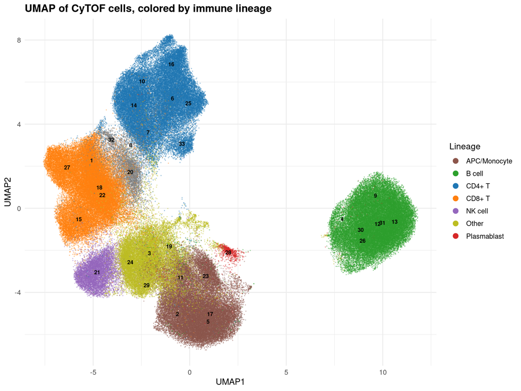

```r
lineage_colors <- c(
  "CD4+ T" = "#1f77b4", "CD8+ T" = "#ff7f0e", "Other" = "#bcbd22",
  "B cell" = "#2ca02c", "Plasmablast" = "#d62728", "NK cell" = "#9467bd",
  "APC/Monocyte" = "#8c564b")

plot_dt <- cbind(data.table(meta = cell_meta), umap_dt)
plot_dt <- merge(plot_dt, ann[, .(cluster_id, annotation, broad_lineage)],
                 by.x = "meta", by.y = "cluster_id", all.x = TRUE)
# One label per cluster, placed at the cluster's median UMAP location.
label_dt <- plot_dt[, .(UMAP1 = median(UMAP1), UMAP2 = median(UMAP2)), by = meta]

ggplot(plot_dt, aes(UMAP1, UMAP2, color = broad_lineage)) +
  geom_point(size = 0.1, alpha = 0.3) +
  geom_text(data = label_dt, aes(UMAP1, UMAP2, label = meta), size = 2.7,
            fontface = "bold", color = "black", inherit.aes = FALSE) +
  scale_color_manual(values = lineage_colors, name = "Lineage") +
  guides(color = guide_legend(override.aes = list(size = 3, alpha = 1))) +
  labs(title = "UMAP of CyTOF cells, colored by immune lineage") +
  theme_minimal(base_size = 12) +
  theme(plot.title = element_text(face = "bold"), legend.position = "right")
```

# 4 Supplementary Figure: faceted UMAP

Highlighting one meta-cluster at a time (red) against the full atlas (gray) confirms that each population is spatially coherent rather than scattered. For rendering speed the gray background is drawn from a uniform random subsample of cells; the highlighted cells are shown in full.

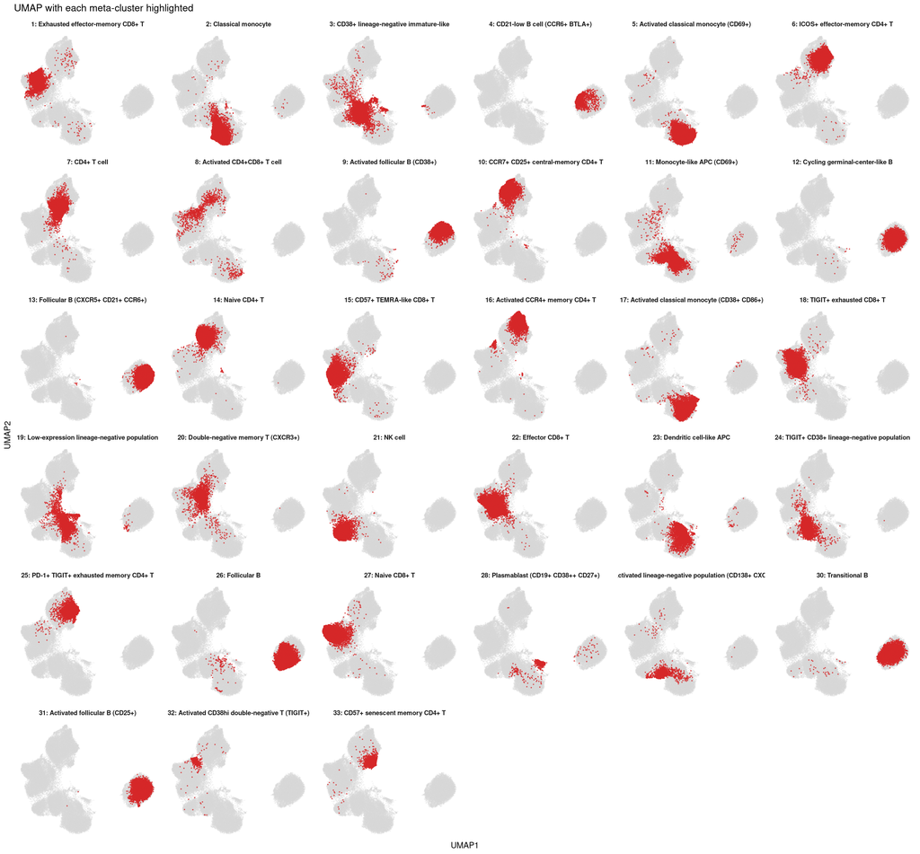

```r
set.seed(1)
# Uniform subsample of the background for a lighter figure (visualization only).
bg_idx <- sample.int(nrow(plot_dt), min(60000L, nrow(plot_dt)))
bg <- plot_dt[bg_idx, .(UMAP1, UMAP2)]

facet_dt <- rbindlist(lapply(sort(unique(plot_dt$meta)), function(cl) {
  hi <- plot_dt[meta == cl, .(UMAP1, UMAP2)]
  lab <- sprintf("%d: %s", cl, ann[cluster_id == cl, annotation])
  rbind(
    data.table(UMAP1 = bg$UMAP1, UMAP2 = bg$UMAP2, highlight = "other", label = lab),
    data.table(UMAP1 = hi$UMAP1, UMAP2 = hi$UMAP2, highlight = "selected", label = lab))
}))
lab_levels <- sprintf("%d: %s", sort(unique(plot_dt$meta)),
                      ann[match(sort(unique(plot_dt$meta)), cluster_id), annotation])
facet_dt[, label := factor(label, levels = lab_levels)]

ggplot(facet_dt, aes(UMAP1, UMAP2)) +
  geom_point(data = facet_dt[highlight == "other"], color = "gray85",
             size = 0.05, alpha = 0.25) +
  geom_point(data = facet_dt[highlight == "selected"], color = "#d62728",
             size = 0.15, alpha = 0.7) +
  facet_wrap(~ label, ncol = 6) +
  labs(title = "UMAP with each meta-cluster highlighted") +
  theme_minimal(base_size = 9) +
  theme(strip.text = element_text(face = "bold", size = 7),
        axis.text = element_blank(), axis.ticks = element_blank(),
        panel.grid = element_blank())
```

# 5 Supplementary Figure: biclustered marker heatmap

Averaging each marker’s expression across the cells in a meta-cluster, then z-scoring across clusters, gives a compact fingerprint of every population. Hierarchical clustering of both axes reveals block structure: B-cell markers co-cluster, T-cell markers co-cluster, and activation markers form their own block.

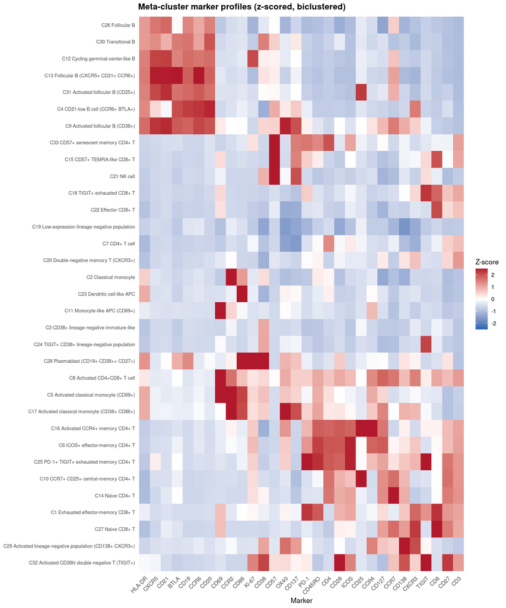

```r
# marker_profiles: rows = clusters (z-space means), cols = markers. Z-score each
# marker across clusters so the color scale is comparable between markers.
mp <- as.data.table(marker_profiles)
mp[, cluster_id := as.integer(gsub("cluster_", "", rownames(marker_profiles)))]
mcols <- setdiff(names(mp), "cluster_id")
for (m in mcols) mp[, (m) := (get(m) - mean(get(m))) / max(sd(get(m)), 1e-8)]

heat_mat <- as.matrix(mp[, ..mcols])
rownames(heat_mat) <- sprintf("C%d %s", mp$cluster_id,
                              ann[match(mp$cluster_id, cluster_id), annotation])
row_order <- rownames(heat_mat)[hclust(dist(heat_mat), "ward.D2")$order]
col_order <- colnames(heat_mat)[hclust(dist(t(heat_mat)), "ward.D2")$order]

heat_long <- melt(mp, id.vars = "cluster_id", variable.name = "marker",
                  value.name = "z")
heat_long[, label := sprintf("C%d %s", cluster_id,
                             ann[match(cluster_id, cluster_id), annotation])]
heat_long[, label := factor(label, levels = rev(row_order))]
heat_long[, marker := factor(marker, levels = col_order)]

ggplot(heat_long, aes(marker, label, fill = z)) +
  geom_tile() +
  scale_fill_gradient2(low = "#2166ac", mid = "white", high = "#b2182b",
                       midpoint = 0, limits = c(-2.5, 2.5),
                       oob = scales::squish, name = "Z-score") +
  labs(title = "Meta-cluster marker profiles (z-scored, biclustered)",
       x = "Marker", y = NULL) +
  theme_minimal(base_size = 10) +
  theme(axis.text.x = element_text(angle = 45, hjust = 1, size = 8),
        axis.text.y = element_text(size = 7),
        plot.title = element_text(face = "bold"))
```

# 6 Cluster biology as an immune-reconstitution proxy

If the meta-clusters capture immune reconstitution, cellular composition should predict how long ago a patient was transplanted. Regressing time since transplant on the CLR composition features quantifies this.

```r
if (file.exists(CTIME_FILE)) {
  # Load the precomputed regression of time-post-transplant on composition.
  ct <- new.env(parent = emptyenv()); load(CTIME_FILE, envir = ct)
  cluster_time_df <- ct$cluster_time_df
  r2 <- ct$fit_time_summary$r.squared
  adj_r2 <- ct$fit_time_summary$adj.r.squared
} else {
  # Self-contained given the composition features and the time covariate.
  stop("Cluster-time regression cache not found (needs time-post-transplant).")
}

cat(sprintf("Variance in time post-transplant explained by composition: R2 = %.3f (adj. R2 = %.3f)\n",
            r2, adj_r2))
```

```
## Variance in time post-transplant explained by composition: R2 = 0.385 (adj. R2 = 0.321)
```

```r
# Strongest individual cluster-time associations (by |Spearman rho|). The
# cluster column is like "cluster_3"; map it to the integer id for the labels.
ct_show <- as.data.table(cluster_time_df)
ct_show[, cluster_id := as.integer(sub("cluster_", "", cluster))]
ct_show <- merge(ct_show, ann[, .(cluster_id, annotation)], by = "cluster_id")
ct_out <- ct_show[order(-abs(spearman_rho))][1:8,
  .(Cluster = cluster_id, `Cell type` = annotation,
    `Spearman rho` = round(spearman_rho, 3),
    `p` = signif(spearman_p, 2))]
kable(ct_out, caption =
  "Strongest associations between meta-cluster composition and time post-transplant.")
```

Strongest associations between meta-cluster composition and time post-transplant.

| Cluster | Cell type | Spearman rho | p |
| --- | --- | --- | --- |
| 3 | CD38+ lineage-negative immature-like | -0.440 | 0e+00 |
| 23 | Dendritic cell-like APC | -0.395 | 0e+00 |
| 27 | Naive CD8+ T | 0.325 | 0e+00 |
| 2 | Classical monocyte | -0.324 | 0e+00 |
| 14 | Naive CD4+ T | 0.322 | 0e+00 |
| 5 | Activated classical monocyte (CD69+) | -0.308 | 0e+00 |
| 17 | Activated classical monocyte (CD38+ CD86+) | -0.290 | 0e+00 |
| 24 | TIGIT+ CD38+ lineage-negative population | -0.268 | 5e-07 |

Composition explains 38.5% of the variance in time since transplant. The strongest associations are a CD38+ lineage-negative population and an HLA-DR+CD86+ dendritic-cell-like APC, both more abundant early after transplant. The meta-clusters therefore carry genuine immune-reconstitution information, linking cellular composition to the vaccine response.